# MIB Exam Project

Ceren Akkaya

```r
library(edgeR)
```

#### 1. Data Import

Reading data and importing them in a proper way is the first step of the analysis.

```r
counts <- read.table(file = "Counts2023.csv", header = T, sep = " ", row.names = 1)
dim(counts) # dim() function shows number of rows and columns
```

```
## [1] 31414    36
```

```r
annot <- read.table(file = "GeneType.csv", header = T, sep = " ")
dim(annot)
```

```
## [1] 31414     3
```

```r
design <- read.table(file = "Metadata2023.csv", header = T, sep = " ", row.names = 1)
dim(design)
```

```
## [1] 36  7
```

Data should be in the same order in each data frame.

```r
row.names(design) <- with(design, paste(donor_id,structure_acronym,sep = "_"))
head(design)
```

```
##            donor_id donor_name    age gender structure_id structure_acronym
## X12841_A1C   X12841 H376.IX.51  8 yrs      M        10236               A1C
## X12289_A1C   X12289 H376.IX.50 11 yrs      F        10236               A1C
## X13057_A1C   X13057 H376.XI.60 21 yrs      F        10236               A1C
## X12290_A1C   X12290 H376.XI.52 30 yrs      F        10236               A1C
## X12302_A1C   X12302 H376.XI.53 36 yrs      M        10236               A1C
## X12303_A1C   X12303 H376.XI.54 37 yrs      M        10236               A1C
##                            structure_name
## X12841_A1C primary auditory cortex (core)
## X12289_A1C primary auditory cortex (core)
## X13057_A1C primary auditory cortex (core)
## X12290_A1C primary auditory cortex (core)
## X12302_A1C primary auditory cortex (core)
## X12303_A1C primary auditory cortex (core)
```

```r
table(colnames(counts)==rownames(design)) #check if they are in the same order or not
```

```
##
## TRUE
##   36
```

```r
rownames(annot) <- annot$ensembl.id
head(annot)
```

```
##                      ensembl.id          symbol           type
## ENSG00000243485 ENSG00000243485     MIR1302-2HG         lncRNA
## ENSG00000237613 ENSG00000237613         FAM138A         lncRNA
## ENSG00000186092 ENSG00000186092           OR4F5 protein_coding
## ENSG00000238009 ENSG00000238009 ENSG00000238009         lncRNA
## ENSG00000241860 ENSG00000241860 ENSG00000241860         lncRNA
## ENSG00000222623 ENSG00000222623      RNU6-1100P          snRNA
```

```r
annot[,1] <- NULL
head(annot)
```

```
##                          symbol           type
## ENSG00000243485     MIR1302-2HG         lncRNA
## ENSG00000237613         FAM138A         lncRNA
## ENSG00000186092           OR4F5 protein_coding
## ENSG00000238009 ENSG00000238009         lncRNA
## ENSG00000241860 ENSG00000241860         lncRNA
## ENSG00000222623      RNU6-1100P          snRNA
```

```r
table(rownames(counts)==rownames(annot))
```

```
##
## FALSE  TRUE
## 31410     4
```

```r
#Rownames are not consistent. To make it consistent, I will order annot dataframe according to rownames of counts dataframe.
annot <- annot[rownames(counts),]
table(rownames(counts)==rownames(annot))
```

```
##
##  TRUE
## 31414
```

#### 2. Filtering Data

Before proceeding, we have to filter our data in a way that keep genes that are expressed with 10 reads or more at least in 1 condition.

```r
exp <- counts >= 10

numberExp <- apply(exp,1,sum)
head(numberExp)
```

```
## ENSG00000243485 ENSG00000237613 ENSG00000186092 ENSG00000238009 ENSG00000222623
##               3               1               7              11               0
## ENSG00000241599
##               0
```

```r
filtCounts <- counts[numberExp>=1,]
head(filtCounts)
```

```
##                 X12841_A1C X12289_A1C X13057_A1C X12290_A1C X12302_A1C
## ENSG00000243485          5          0          3          1          6
## ENSG00000237613          1          0          2          1          5
## ENSG00000186092          5         21          6          1          2
## ENSG00000238009         14          6          3          3         10
## ENSG00000235146          2          0          2          1          5
## ENSG00000237491         76         79        110        130         80
##                 X12303_A1C X12841_AMY X12289_AMY X13057_AMY X12290_AMY
## ENSG00000243485          6          3          1          1          0
## ENSG00000237613          2          3          3          2          0
## ENSG00000186092          3          1          7          3          2
## ENSG00000238009         14         13          4          4          6
## ENSG00000235146          3          1          0          3          0
## ENSG00000237491         84         77        110        143        157
##                 X12302_AMY X12303_AMY X12841_DFC X12289_DFC X13057_DFC
## ENSG00000243485         20          5          3          2          1
## ENSG00000237613          7          5          2          0          3
## ENSG00000186092          5          8          2         15          1
## ENSG00000238009          8          9         14          0          4
## ENSG00000235146         11          9          3          1          1
## ENSG00000237491        148        113        100         75        119
##                 X12290_DFC X12302_DFC X12303_DFC X12841_HIP X12289_HIP
## ENSG00000243485          0         12          4          6          2
## ENSG00000237613          0          8          3          2          1
## ENSG00000186092          1          1          5          2         16
## ENSG00000238009         18         11          8         24         11
## ENSG00000235146          0          9          2          4          0
## ENSG00000237491        137        103        135        149         89
##                 X13057_HIP X12290_HIP X12302_HIP X12303_HIP X12841_IPC
## ENSG00000243485          2          2          2          2          5
## ENSG00000237613          0          1          2          5          3
## ENSG00000186092          0          0          6         14          5
## ENSG00000238009          7          4          5          5         28
## ENSG00000235146          1          0          1          4          7
## ENSG00000237491         55        184         81        109        121
##                 X12289_IPC X13057_IPC X12290_IPC X12302_IPC X12303_IPC
## ENSG00000243485          1          1          1         13          5
## ENSG00000237613          0          0          0         15          1
## ENSG00000186092         22          2          3         14          8
## ENSG00000238009         15          4          4          7          7
## ENSG00000235146          4          4          1         12          5
## ENSG00000237491        105        133        137        107         58
##                 X12841_ITC X12289_ITC X13057_ITC X12290_ITC X12302_ITC
## ENSG00000243485          1          1          0          2          2
## ENSG00000237613          1          2          2          0          1
## ENSG00000186092          0         16          1          1          1
## ENSG00000238009          3          2          5          3          6
## ENSG00000235146          0          4          4          6          2
## ENSG00000237491         50         68         86         64         71
##                 X12303_ITC
## ENSG00000243485          8
## ENSG00000237613          4
## ENSG00000186092          0
## ENSG00000238009          8
## ENSG00000235146          6
## ENSG00000237491         50
```

```r
dim(filtCounts)
```

```
## [1] 22030    36
```

#### 3. Creating DGEList Object

Now DGEList Object is created. It is a specific object in edgeR and it is generally used for differential gene expression analysis. This object contains all the data from counts and design. Counts parameter in DGEList function takes your count table as an argument. Group parameter is for defining experimental conditions or your group which will you use for differential gene expression analysis. In that way, result of a DGEList object gives the group information along with the count data.

```r
y = DGEList(counts = filtCounts, group = design$structure_acronym)
attributes(y) #Attributes function allows you to see what you have in your object.
```

```
## $class
## [1] "DGEList"
## attr(,"package")
## [1] "edgeR"
##
## $names
## [1] "counts"  "samples"
```

```r
head(y$samples)
```

```
##            group lib.size norm.factors
## X12841_A1C   A1C 56527006            1
## X12289_A1C   A1C 37829045            1
## X13057_A1C   A1C 38115174            1
## X12290_A1C   A1C 45498115            1
## X12302_A1C   A1C 30822617            1
## X12303_A1C   A1C 39372997            1
```

#### 3. Normalization

Normalization is needed to make our data more comparable. EdgeR has a specific function which is calcNormFactors() to normalize count data. This function calculate normalization factors. In that way, library size differences or sequencing depth in samples is optimized.

```r
y=calcNormFactors(y)
head(y$samples)
```

```
##            group lib.size norm.factors
## X12841_A1C   A1C 56527006    0.9895392
## X12289_A1C   A1C 37829045    0.9901271
## X13057_A1C   A1C 38115174    1.0240923
## X12290_A1C   A1C 45498115    1.0846145
## X12302_A1C   A1C 30822617    1.0238842
## X12303_A1C   A1C 39372997    0.9712900
```

#### 4. PCA Analysis

As you can see, there are many data in our object. If we try to understand expression profile of each tissue type with just regression analysis, we cannot make a good interpratation. Because of this, we have to do reduction of dimensionality in our data. To do so, we would visualize the similarity or dissimilarity between samples based on their gene expression profiles. plotMDS is a is function of edgeR which provides dimensionality reduction on our data.

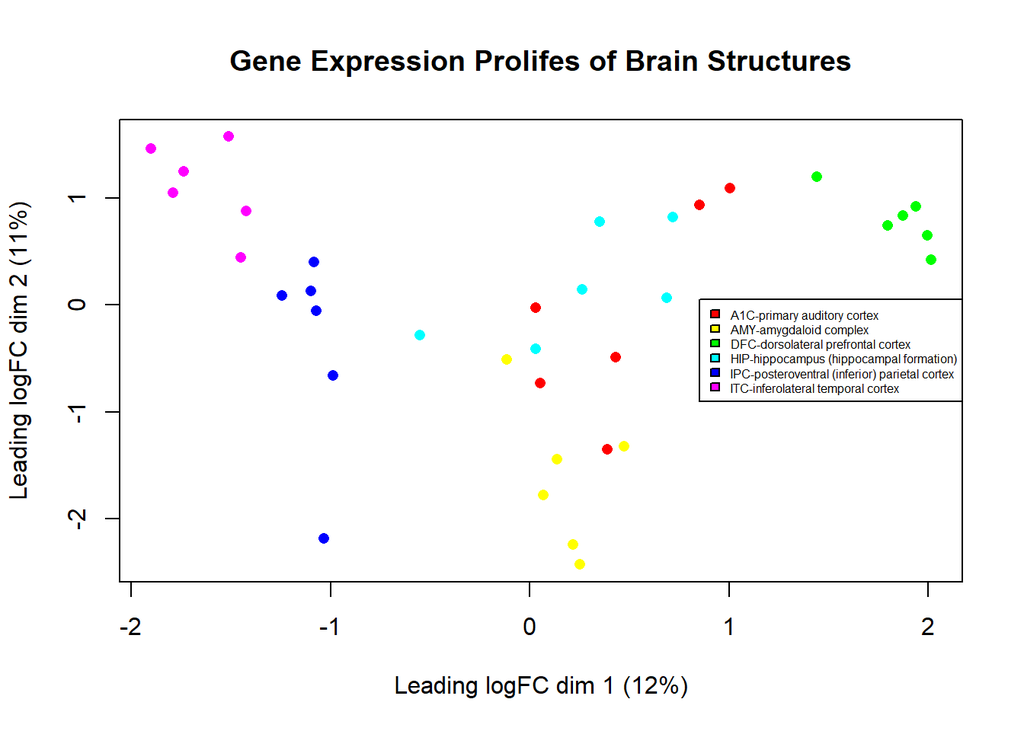

```r
plotMDS(y, col=rep(rainbow(6), each=6), pch = 16, main="Gene Expression Prolifes of Brain Structures")
legend("right", legend = c("A1C-primary auditory cortex", "AMY-amygdaloid complex", "DFC-dorsolateral prefrontal cortex", "HIP-hippocampus (hippocampal formation)", "IPC-posteroventral (inferior) parietal cortex", "ITC-inferolateral temporal cortex"), fill = rainbow(6), cex=0.5)
```

For further analysis, two different brain structures should be choosen. To make a meaningful choice, we have to consider both the distance between each tissue/brain structure types and also distance between the samples of the same tissue. To get significantly differentially expressed genes, the more distance between different tissue types and more clustered region between samples of the same tissue is necessary. For that reason, ITC and DFC are the best candidates.

#### 5. Differential Expression Analysis between ITC and DFC.

Now we can do the differential expression analysis with these two tissue types. We do the test first by estimating our statistical model which is Negative Binomial model with estimateDisp() function of edgeR to compute p-value.

```r
y=estimateDisp(y)
```

```
## Using classic mode.
```

After that the function exactTest() is for making a differential expression test with pairwise comparison. Pairwise comparison is considering two tissues that seem to have a significant expression difference in the plot.

```r
DE_tissues1 <- exactTest(y, pair = c("ITC","DFC"))
```

```r
attributes(DE_tissues1)
```

```
## $class
## [1] "DGEExact"
## attr(,"package")
## [1] "edgeR"
##
## $names
## [1] "table"      "comparison" "genes"
```

```r
head(DE_tissues1)
```

```
## An object of class "DGEExact"
## $table
##                      logFC    logCPM    PValue
## ENSG00000243485  0.3141190 -3.061047 0.7453910
## ENSG00000237613  0.2941284 -3.392088 0.8397063
## ENSG00000186092 -0.2245311 -2.588493 0.8647918
## ENSG00000238009  0.6055543 -2.213227 0.3466067
## ENSG00000235146 -0.7299893 -3.144591 0.4686917
## ENSG00000237491  0.3558107  1.170609 0.2083711
##
## $comparison
## [1] "ITC" "DFC"
```

Then, False Discovery Rate (FDR) should be calculated. FDR is used to control of falsely identified differentially expressed genes which are called false positives. topTags() function is used to calculate FDR. FDR is used as a p-value threshold to say that a gene is differentially expressed. So, by FDR we can see if the difference is significant or not. The threshold has to be < 0.01 or 0.05

```r
result1<-topTags(DE_tissues1, n=nrow(DE_tissues1))
DEgenes1<-result1[result1$table$FDR<=0.01,]
dim(DEgenes1)
```

```
## [1] 7195    4
```

We can see that 7195 genes show a difference between ITC and DFC according to their expression levels.

```r
head(DEgenes1)
```

```
## Comparison of groups:  DFC-ITC
##                     logFC   logCPM       PValue          FDR
## ENSG00000081189  3.797042 6.933633 1.163892e-55 2.564053e-51
## ENSG00000157470  3.393393 5.027557 1.139268e-46 1.103037e-42
## ENSG00000151090  3.486470 5.766025 1.502093e-46 1.103037e-42
## ENSG00000109670  3.102768 6.586822 1.150035e-45 6.333817e-42
## ENSG00000167081 -2.642194 5.055567 7.290737e-43 3.212299e-39
## ENSG00000119125  6.885186 6.028692 1.985411e-34 7.289768e-31
```

#### 6. Groupping Genes and Creating Box-Plot

Group genes in 4 groups depending on the logFC value so that we can build the boxplot. logFC value is to understand whether the gene is upregulated or downregulated.

*logFC > 0 : the gene is upregulated

*logFC < 0 : the gene is downregulated

```r
data_DE <- result1$table
```

```r
UP_DE <- data_DE[data_DE$FDR<=0.01 & data_DE$logFC>0,"logFC"]
UP_notDE <- data_DE[data_DE$FDR>0.01 & data_DE$logFC>0,"logFC"]
DOWN_DE <- data_DE[data_DE$FDR<=0.01 & data_DE$logFC<0,"logFC"]
DOWN_notDE <- data_DE[data_DE$FDR>0.01 & data_DE$logFC<0,"logFC"]
```

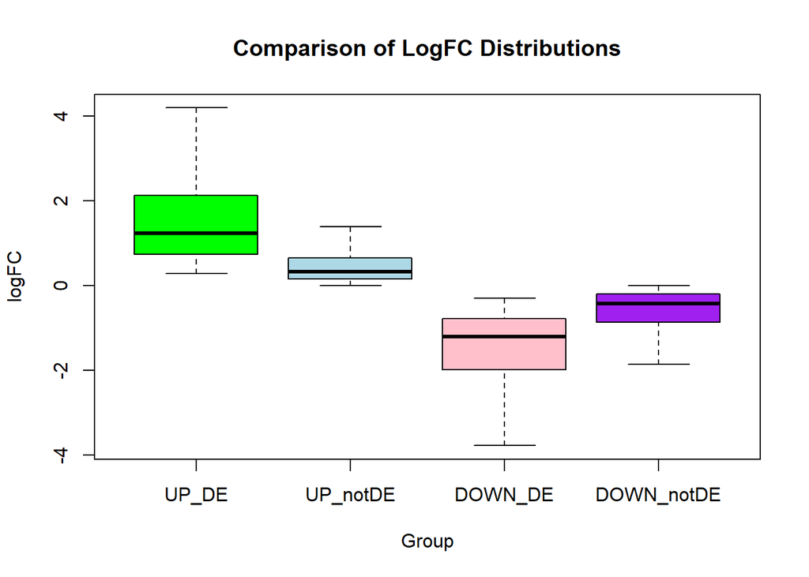

```r
boxplot(UP_DE,UP_notDE,DOWN_DE,DOWN_notDE, outline=FALSE, col = c("green","lightblue","pink","purple"), names=c("UP_DE","UP_notDE","DOWN_DE","DOWN_notDE"), main="Comparison of LogFC Distributions", ylab="logFC", xlab="Group")
```

With boxplot we visualize and compare the distribution of gene expression levels between different groups. In this way, we can easily identify differences in expression patterns. We can make some interpretation from the plot.

*1. Upregulated DE or Not DE genes has higher logFC than downregulated genes as expected.

*2. Differentially expressed genes have a bigger change in expression than the genes that are not differentially expressed.

How many genes do we have in each gene class?

```r
table(annot$type)
```

```
##
##                          IG_D_gene                          IG_J_gene
##                                  9                                  4
##                    IG_J_pseudogene                          IG_V_gene
##                                  1                                 19
##                    IG_V_pseudogene                             lncRNA
##                                 22                               7167
##                              miRNA                           misc_RNA
##                               1139                                254
##                            Mt_rRNA                            Mt_tRNA
##                                  1                                  3
##               processed_pseudogene                     protein_coding
##                               1405                              18754
##                           ribozyme                               rRNA
##                                  1                                  2
##                    rRNA_pseudogene                             scaRNA
##                                 84                                  7
##                             snoRNA                              snRNA
##                                152                               1783
##                                TEC                          TR_C_gene
##                                  1                                  2
##                          TR_D_gene                          TR_J_gene
##                                  1                                 15
##                    TR_J_pseudogene                          TR_V_gene
##                                  2                                  7
##                    TR_V_pseudogene   transcribed_processed_pseudogene
##                                  6                                 62
##     transcribed_unitary_pseudogene transcribed_unprocessed_pseudogene
##                                 34                                152
##  translated_unprocessed_pseudogene                 unitary_pseudogene
##                                  1                                  9
##             unprocessed_pseudogene
##                                315
```

How many genes are DE in a class?

```r
DEgenetype <- merge(DEgenes1,annot,by=0,all=FALSE)
head(DEgenetype)
```

```
##         Row.names      logFC   logCPM       PValue          FDR   symbol
## 1 ENSG00000000460 -1.1008495 1.888383 7.388463e-06 4.586302e-05 C1orf112
## 2 ENSG00000001036 -1.3147966 4.416948 1.247846e-14 6.305055e-13    FUCA2
## 3 ENSG00000001084 -0.7815708 5.859473 1.814557e-04 7.833565e-04     GCLC
## 4 ENSG00000001461 -1.1402774 7.711488 9.298497e-06 5.624544e-05   NIPAL3
## 5 ENSG00000001561 -1.1112518 6.201824 1.052187e-05 6.289914e-05    ENPP4
## 6 ENSG00000001626 -2.6713677 1.476206 1.132194e-08 1.377263e-07     CFTR
##             type
## 1 protein_coding
## 2 protein_coding
## 3 protein_coding
## 4 protein_coding
## 5 protein_coding
## 6 protein_coding
```

```r
table(DEgenetype$type)
```

```
##
##                             lncRNA               processed_pseudogene
##                                623                                  5
##                     protein_coding                              snRNA
##                               6557                                  1
##     transcribed_unitary_pseudogene transcribed_unprocessed_pseudogene
##                                  3                                  5
##             unprocessed_pseudogene
##                                  1
```

As you can see, most of the DE genes are belongs to protein coding gene class. Protein coding genes encode proteins that perform a many different essential functions in various biological processes.For example, cell signaling, metabolism, development, and response to stimuli. Differences in tissue types often result from variations in gene expression levels of these protein coding genes. This fact shows that different tissues have the distinct cellular functions and phenotypes. So the result is an expected result because we are analyzing two different brain structures.

### PROJECT 1

```r
library(dplyr) #load dplyr package to use filter function
```

For this project, goal is to identify genes showing sex specific expression in the 2 tissues. My tissues are DFC and ITC. To do so, firstly, I create new design and count table according to data I want.

```r
designTissue <- filter(design, structure_acronym %in% c("DFC","ITC"))  #by filter function I choose and extract data only I want
head(designTissue)
```

```
##            donor_id donor_name    age gender structure_id structure_acronym
## X12841_DFC   X12841 H376.IX.51  8 yrs      M        10173               DFC
## X12289_DFC   X12289 H376.IX.50 11 yrs      F        10173               DFC
## X13057_DFC   X13057 H376.XI.60 21 yrs      F        10173               DFC
## X12290_DFC   X12290 H376.XI.52 30 yrs      F        10173               DFC
## X12302_DFC   X12302 H376.XI.53 36 yrs      M        10173               DFC
## X12303_DFC   X12303 H376.XI.54 37 yrs      M        10173               DFC
##                            structure_name
## X12841_DFC dorsolateral prefrontal cortex
## X12289_DFC dorsolateral prefrontal cortex
## X13057_DFC dorsolateral prefrontal cortex
## X12290_DFC dorsolateral prefrontal cortex
## X12302_DFC dorsolateral prefrontal cortex
## X12303_DFC dorsolateral prefrontal cortex
```

```r
countsTissue <- counts[,rownames(designTissue)] #reorder and extract count table column according to rownames of new design table
head(countsTissue)
```

```
##                 X12841_DFC X12289_DFC X13057_DFC X12290_DFC X12302_DFC
## ENSG00000243485          3          2          1          0         12
## ENSG00000237613          2          0          3          0          8
## ENSG00000186092          2         15          1          1          1
## ENSG00000238009         14          0          4         18         11
## ENSG00000222623          0          0          1          0          0
## ENSG00000241599          1          0          0          0          0
##                 X12303_DFC X12841_ITC X12289_ITC X13057_ITC X12290_ITC
## ENSG00000243485          4          1          1          0          2
## ENSG00000237613          3          1          2          2          0
## ENSG00000186092          5          0         16          1          1
## ENSG00000238009          8          3          2          5          3
## ENSG00000222623          0          0          0          0          0
## ENSG00000241599          1          0          2          0          0
##                 X12302_ITC X12303_ITC
## ENSG00000243485          2          8
## ENSG00000237613          1          4
## ENSG00000186092          1          0
## ENSG00000238009          6          8
## ENSG00000222623          0          0
## ENSG00000241599          0          0
```

Proceed with the filtering data like common part. But in this case, for each tissue, consider only genes expressed (>10 reads in at least 2 replicates) in that tissue.

```r
exp2 <- countsTissue>=10
numberExp2 <- apply(exp2,1,sum)
filtCounts2 <- countsTissue[numberExp2>=2,]
head(filtCounts2)
```

```
##                 X12841_DFC X12289_DFC X13057_DFC X12290_DFC X12302_DFC
## ENSG00000186092          2         15          1          1          1
## ENSG00000238009         14          0          4         18         11
## ENSG00000237491        100         75        119        137        103
## ENSG00000177757          8          8         15         33         13
## ENSG00000225880        110         78        114        119         94
## ENSG00000230368         12          7         13          3         12
##                 X12303_DFC X12841_ITC X12289_ITC X13057_ITC X12290_ITC
## ENSG00000186092          5          0         16          1          1
## ENSG00000238009          8          3          2          5          3
## ENSG00000237491        135         50         68         86         64
## ENSG00000177757          6         12         13          9         14
## ENSG00000225880         56         68         71        147        155
## ENSG00000230368          8          0          3          6          1
##                 X12302_ITC X12303_ITC
## ENSG00000186092          1          0
## ENSG00000238009          6          8
## ENSG00000237491         71         50
## ENSG00000177757          4         11
## ENSG00000225880         95         74
## ENSG00000230368          4          9
```

```r
dim(filtCounts2)
```

```
## [1] 19722    12
```

I have created a new column for my dataframe. This column will include the data structure acronym with gender data.

```r
groupName <- factor(paste(designTissue$structure_acronym, designTissue$gender, sep = "-"))
groupName
```

```
##  [1] DFC-M DFC-F DFC-F DFC-F DFC-M DFC-M ITC-M ITC-F ITC-F ITC-F ITC-M ITC-M
## Levels: DFC-F DFC-M ITC-F ITC-M
```

Add new column to the dataframe of desingTissue.

```r
designTissue$groupName <- groupName
head(designTissue)
```

```
##            donor_id donor_name    age gender structure_id structure_acronym
## X12841_DFC   X12841 H376.IX.51  8 yrs      M        10173               DFC
## X12289_DFC   X12289 H376.IX.50 11 yrs      F        10173               DFC
## X13057_DFC   X13057 H376.XI.60 21 yrs      F        10173               DFC
## X12290_DFC   X12290 H376.XI.52 30 yrs      F        10173               DFC
## X12302_DFC   X12302 H376.XI.53 36 yrs      M        10173               DFC
## X12303_DFC   X12303 H376.XI.54 37 yrs      M        10173               DFC
##                            structure_name groupName
## X12841_DFC dorsolateral prefrontal cortex     DFC-M
## X12289_DFC dorsolateral prefrontal cortex     DFC-F
## X13057_DFC dorsolateral prefrontal cortex     DFC-F
## X12290_DFC dorsolateral prefrontal cortex     DFC-F
## X12302_DFC dorsolateral prefrontal cortex     DFC-M
## X12303_DFC dorsolateral prefrontal cortex     DFC-M
```

Then, as in the common part, we proceed with creating our object. In this one, group is made by groupName.

```r
DGE_List2 <- DGEList(counts = filtCounts2, group = designTissue$groupName)
head(DGE_List2$samples)
```

```
##            group lib.size norm.factors
## X12841_DFC DFC-M 64026573            1
## X12289_DFC DFC-F 53012727            1
## X13057_DFC DFC-F 61437736            1
## X12290_DFC DFC-F 49839970            1
## X12302_DFC DFC-M 43396879            1
## X12303_DFC DFC-M 45398173            1
```

Continue with Normalization.

```r
DGE_List2 <- calcNormFactors(DGE_List2)
DGE_List2$samples$norm.factors
```

```
##  [1] 0.9533810 0.9604495 1.0046747 1.0258391 1.0127836 1.0412235 1.0626832
##  [8] 0.9960033 1.0479755 1.0538963 0.9553265 0.8997633
```

And then I perform PCA analysis to understand the difference between two sexes in these two tissues.

```r
mycolors <- c()   #Create colors with for loop for PCA plot.

for (i in designTissue$groupName){
  if(i == "DFC-M"){
    mycolors <- c(mycolors, "blue")}
  else if (i == "DFC-F"){
    mycolors <- c(mycolors, "violet")}
  else if (i == "ITC-M"){
    mycolors <- c(mycolors, "red")}
  else if (i == "ITC-F"){
    mycolors <- c(mycolors, "turquoise")}}
```

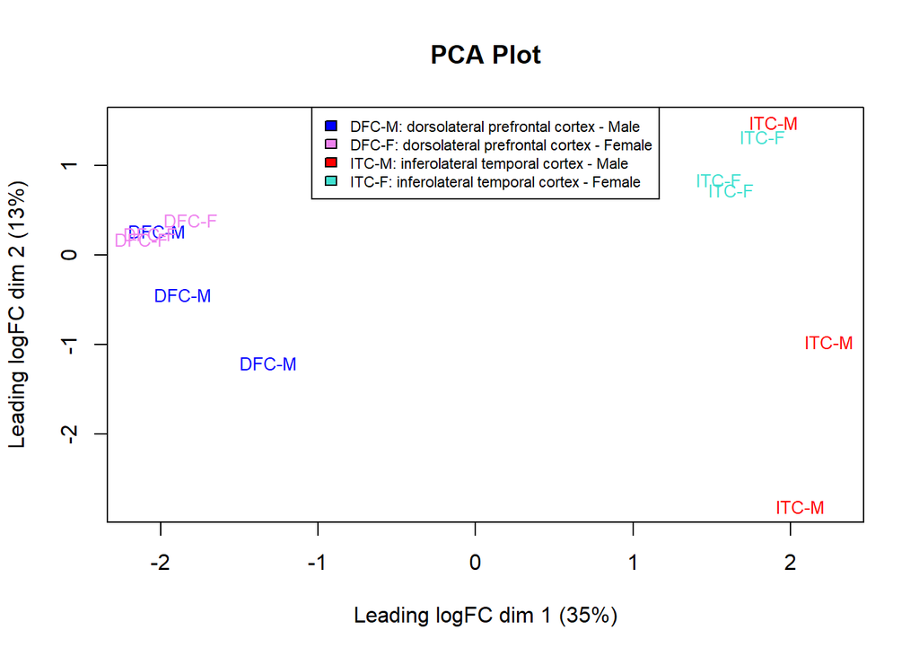

```r
plotMDS(DGE_List2, labels = DGE_List2$samples$group, col=mycolors, cex = 0.8, main="PCA Plot")
legend("top", legend = c("DFC-M: dorsolateral prefrontal cortex - Male", "DFC-F: dorsolateral prefrontal cortex - Female","ITC-M: inferolateral temporal cortex - Male", "ITC-F: inferolateral temporal cortex - Female" ), fill = unique(mycolors), cex=0.7)
```

Proceed analysis with the Male-Female comparison in tissue DFC

Redesign data according to DFC data

```r
designDFC <- design[design$structure_acronym=="DFC",]
head(designDFC)
```

```
##            donor_id donor_name    age gender structure_id structure_acronym
## X12841_DFC   X12841 H376.IX.51  8 yrs      M        10173               DFC
## X12289_DFC   X12289 H376.IX.50 11 yrs      F        10173               DFC
## X13057_DFC   X13057 H376.XI.60 21 yrs      F        10173               DFC
## X12290_DFC   X12290 H376.XI.52 30 yrs      F        10173               DFC
## X12302_DFC   X12302 H376.XI.53 36 yrs      M        10173               DFC
## X12303_DFC   X12303 H376.XI.54 37 yrs      M        10173               DFC
##                            structure_name
## X12841_DFC dorsolateral prefrontal cortex
## X12289_DFC dorsolateral prefrontal cortex
## X13057_DFC dorsolateral prefrontal cortex
## X12290_DFC dorsolateral prefrontal cortex
## X12302_DFC dorsolateral prefrontal cortex
## X12303_DFC dorsolateral prefrontal cortex
```

```r
countsDFC <- counts[,rownames(designDFC)]
head(countsDFC)
```

```
##                 X12841_DFC X12289_DFC X13057_DFC X12290_DFC X12302_DFC
## ENSG00000243485          3          2          1          0         12
## ENSG00000237613          2          0          3          0          8
## ENSG00000186092          2         15          1          1          1
## ENSG00000238009         14          0          4         18         11
## ENSG00000222623          0          0          1          0          0
## ENSG00000241599          1          0          0          0          0
##                 X12303_DFC
## ENSG00000243485          4
## ENSG00000237613          3
## ENSG00000186092          5
## ENSG00000238009          8
## ENSG00000222623          0
## ENSG00000241599          1
```

Filtering data

```r
expDFC <- countsDFC >= 10

numberExp_DFC <- apply(expDFC,1,sum)

filtCounts_DFC <- countsDFC[numberExp_DFC>=2,]

head(filtCounts_DFC)
```

```
##                 X12841_DFC X12289_DFC X13057_DFC X12290_DFC X12302_DFC
## ENSG00000238009         14          0          4         18         11
## ENSG00000237491        100         75        119        137        103
## ENSG00000177757          8          8         15         33         13
## ENSG00000225880        110         78        114        119         94
## ENSG00000230368         12          7         13          3         12
## ENSG00000230699         26         19         36         10         19
##                 X12303_DFC
## ENSG00000238009          8
## ENSG00000237491        135
## ENSG00000177757          6
## ENSG00000225880         56
## ENSG00000230368          8
## ENSG00000230699         21
```

Create DGEList and grouped by gender

```r
y_DFC <- DGEList(counts=filtCounts_DFC, group = designDFC$gender)

attributes(y_DFC)
```

```
## $class
## [1] "DGEList"
## attr(,"package")
## [1] "edgeR"
##
## $names
## [1] "counts"  "samples"
```

Normalization

```r
y_DFC <- calcNormFactors(y_DFC)
```

Estimate statistical test (NB)

```r
y_DFC <- estimateDisp(y_DFC)
```

```
## Using classic mode.
```

Now, differentially expression analysis for DFC Male and Female samples by calculating FDR and making comparison.

```r
DFC_DE <- exactTest(y_DFC, pair = c("M","F"))

DFC_DE$comparison
```

```
## [1] "M" "F"
```

```r
head(DFC_DE$table)
```

```
##                      logFC    logCPM    PValue
## ENSG00000238009 -0.6285966 -2.224442 0.6153034
## ENSG00000237491 -0.1669950  1.130701 0.7111423
## ENSG00000177757  0.9228306 -1.720975 0.2684928
## ENSG00000225880  0.1581805  0.881161 0.7303078
## ENSG00000230368 -0.6192148 -2.239511 0.4110701
## ENSG00000230699 -0.1671849 -1.158250 0.7966933
```

Add FDR

```r
DFC_DEGs=topTags(DFC_DE, n=nrow(DFC_DE))
DFC_DEGs$comparison
```

```
## [1] "M" "F"
```

```r
compare <- ifelse(DFC_DEGs$table$FDR<=0.05, print("DEG"), print("Not DEG")) #if FDR of genes are lower than or equal to 0.05 print DEG for each of them, if not print Not DEG.
```

```
## [1] "DEG"
## [1] "Not DEG"
```

```r
table(compare)
```

```
## compare
##     DEG Not DEG
##      29   18723
```

As you can see, for DFC tissue 29 genes are sex specific DE genes. Make a list of genes that are sex specific differentially expressed.

```r
significantGenes_DFC = DFC_DEGs[DFC_DEGs$table$FDR<=0.05,] #store these genes in a variable
```

Proceed with the second tissue (ITC) and repeat the same steps of DFC.

```r
designITC <- design[design$structure_acronym=="ITC",]
head(designITC)
```

```
##            donor_id donor_name    age gender structure_id structure_acronym
## X12841_ITC   X12841 H376.IX.51  8 yrs      M        10252               ITC
## X12289_ITC   X12289 H376.IX.50 11 yrs      F        10252               ITC
## X13057_ITC   X13057 H376.XI.60 21 yrs      F        10252               ITC
## X12290_ITC   X12290 H376.XI.52 30 yrs      F        10252               ITC
## X12302_ITC   X12302 H376.XI.53 36 yrs      M        10252               ITC
## X12303_ITC   X12303 H376.XI.54 37 yrs      M        10252               ITC
##                                               structure_name
## X12841_ITC inferolateral temporal cortex (area TEv, area 20)
## X12289_ITC inferolateral temporal cortex (area TEv, area 20)
## X13057_ITC inferolateral temporal cortex (area TEv, area 20)
## X12290_ITC inferolateral temporal cortex (area TEv, area 20)
## X12302_ITC inferolateral temporal cortex (area TEv, area 20)
## X12303_ITC inferolateral temporal cortex (area TEv, area 20)
```

```r
countsITC <- counts[,rownames(designITC)]
head(countsITC)
```

```
##                 X12841_ITC X12289_ITC X13057_ITC X12290_ITC X12302_ITC
## ENSG00000243485          1          1          0          2          2
## ENSG00000237613          1          2          2          0          1
## ENSG00000186092          0         16          1          1          1
## ENSG00000238009          3          2          5          3          6
## ENSG00000222623          0          0          0          0          0
## ENSG00000241599          0          2          0          0          0
##                 X12303_ITC
## ENSG00000243485          8
## ENSG00000237613          4
## ENSG00000186092          0
## ENSG00000238009          8
## ENSG00000222623          0
## ENSG00000241599          0
```

Filtering

```r
expITC <- countsITC >= 10

numberExp_ITC <- apply(expITC,1,sum)

filtCounts_ITC <- countsITC[numberExp_ITC>=2,]

head(filtCounts_ITC)
```

```
##                 X12841_ITC X12289_ITC X13057_ITC X12290_ITC X12302_ITC
## ENSG00000237491         50         68         86         64         71
## ENSG00000177757         12         13          9         14          4
## ENSG00000225880         68         71        147        155         95
## ENSG00000230699          9         16          5         12         11
## ENSG00000223764         15         29         41         41         51
## ENSG00000187634         50         90        276        136        158
##                 X12303_ITC
## ENSG00000237491         50
## ENSG00000177757         11
## ENSG00000225880         74
## ENSG00000230699         10
## ENSG00000223764         46
## ENSG00000187634         97
```

```r
y_ITC <- DGEList(counts=filtCounts_ITC, group = designITC$gender)

attributes(y_ITC)
```

```
## $class
## [1] "DGEList"
## attr(,"package")
## [1] "edgeR"
##
## $names
## [1] "counts"  "samples"
```

```r
y_ITC <- calcNormFactors(y_ITC)
y_ITC <- estimateDisp(y_ITC)
```

```
## Using classic mode.
```

```r
ITC_DE <- exactTest(y_ITC, pair = c("M","F"))

ITC_DE$comparison
```

```
## [1] "M" "F"
```

```r
head(ITC_DE$table)
```

```
##                       logFC       logCPM    PValue
## ENSG00000237491  0.05097657  0.762995670 0.9345526
## ENSG00000177757  0.24186172 -1.698915610 0.7441109
## ENSG00000225880  0.27088571  1.330875463 0.5705946
## ENSG00000230699 -0.02752121 -1.637826995 1.0000000
## ENSG00000223764 -0.35699560 -0.006488168 0.6104761
## ENSG00000187634  0.26331170  1.736287858 0.6875447
```

Calculate FDR

```r
ITC_DEGs=topTags(ITC_DE, n=nrow(ITC_DE))
ITC_DEGs$comparison
```

```
## [1] "M" "F"
```

```r
compare2 <- ifelse(ITC_DEGs$table$FDR<=0.05, print("DEG"), print("Not DEG"))
```

```
## [1] "DEG"
## [1] "Not DEG"
```

```r
table(compare2)
```

```
## compare2
##     DEG Not DEG
##      31   18658
```

There are 31 sex specific DE genes for ITC brain structure.

```r
significantGenes_ITC = ITC_DEGs[ITC_DEGs$table$FDR<=0.05,] #store these genes in a variable
```

#### Draw a Venn Diagram of the Sex specific genes between the 2 tissues

Load Venn Diagram library

```r
library(VennDiagram)
```

Create a list of your sex specific significant genes in both tissues. These genes are already stored them in a “significantGenes_DFC” and “significantGenes_ITC”

```r
myList <- list(rownames(significantGenes_DFC), rownames(significantGenes_ITC))
```

Draw the Venn Diagram of the Sex specific genes between the 2 tissues.

```r
venn.diagram(myList, filename = "Venn Diagram.png", imagetype="png", category.names = c("Sex Specific Genes in DFC","Sex Specific Genes in ITC"), main = "Sex Specific Differentially Expressed Genes Between DFC and ITC Brain Structures", col=c("darkgreen","coral"), fill=c("darkseagreen1","antiquewhite1"), cat.pos=c(-5,5), cat.dist = c(0.01,0.01))
```

```
## [1] 1
```

```r
myList2 <- list(rownames(significantGenes_ITC), rownames(significantGenes_DFC), rownames(DEgenes1))
```

```r
venn.diagram(myList2, filename = "Venn Diagram DE Genes.png", imagetype="png", category.names = c("Sex Specific ITC","Sex Specific DFC", "DE Genes"), main = "Comparison of DEGs Between ITC and DFC and Sex Specific DEGs", col=c("darkblue","darkgoldenrod1", "darkgreen"), fill=c("azure2","lightgoldenrodyellow", "white"), cex = 1.5)
```

```
## [1] 1
```